# Сеетевые технологии

Лабораторная работа №8

Тойчубекова Асель Нурлановна

kulyabov-ds@rudn.ru

Российский университет дружбы народов

2025-12-21

# Информация

## Докладчик

- Тойчубекова Асель Нурлановна
- Студент 3 курса
- факультет физико-математических и естественных наук
- Российский университет дружбы народов им. П. Лумумбы
- 1032235033@rudn.ru

# Цель работы

## Цель работы

Целью данной лабораторной работы является изучение принципов маршрутизации в IPv4- и IPv6-сетях и принципов настройки сетевого оборудования.

# Задание

## Задание

1. Требуется настроить динамическую маршрутизацию по протоколам RIP OSPF.
2. Требуется организовать туннель IPv6 поверх IPv4, позволяющий передавать данные из одной IPv6-сети в другую IPv6-сеть через сеть IPv4.
3. Выполнить задание для самостоятельного выполнения.

# Теоретическое введение

## Теоретическое введение

При организации сетей передачи данных важную роль играет корректное понимание функций и различий между устройствами DTE (Data Terminal Equipment) и DCE (Data Circuit-terminating Equipment), а также принципов синхронизации и правил планирования сетевой инфраструктуры.

Оконечное оборудование данных (DTE) представляет собой устройства, обеспечивающие интерфейс с пользователем и выполняющие прикладные программы. К ним относятся персональные компьютеры, терминалы, сетевые узлы, которые формируют и обрабатывают информационные потоки. Оконечное оборудование канала данных (DCE) служит для подключения DTE к каналам связи, обеспечивая преобразование, усиление и передачу сигналов. В современных сетях маршрутизаторы с последовательными интерфейсами могут выполнять функции как DTE, так и DCE, поэтому корректнее говорить о типе интерфейса, а не устройства.

## Теоретическое введение

Важным аспектом является организация сигнальных цепей. Для интерфейсов типа DTE передающий сигнал TxD является выходным, а принимающий RxD — входным; для DCE — наоборот. Это определяет особенности соединения устройств: при связке DTE–DCE сигналы соединяются напрямую, а при соединениях однотипных устройств — перекрёстно.

Режимы передачи могут быть асинхронными и синхронными. В асинхронном режиме синхронизация обеспечивается старт-битами, тогда как в синхронном используется внешняя синхронизация с отдельными сигналами для передачи и приёма данных (ST и RT). Источником синхронизации обычно выступает устройство DCE, однако возможны различные варианты организации синхросигналов, включая использование сигнала TT и компенсацию фазовых перекосов.

## Теоретическое введение

Наряду с вопросами интерфейсов и синхронизации ключевым этапом построения сетевой инфраструктуры является её планирование и документирование. Проектирование сети предполагает разработку схем трёх уровней модели OSI: физического (L1), канального (L2) и сетевого (L3). Необходимо определить топологию подключения, структуру VLAN, схему адресации и план назначения интерфейсов. Чёткое и детализированное документирование обеспечивает корректную эксплуатацию сети, упрощает администрирование и позволяет эффективно решать задачи модернизации и диагностики.

# Выполнение лабораторной работы

## Настройка динамической маршрутизации в сетях IPv4 и IPv6

У нас задана сеть, адреса сегментов сети, адреса, назначаемые интерфейсам устройств.

[figure not shown]

Топология сети

## Настройка динамической маршрутизации в сетях IPv4 и IPv6

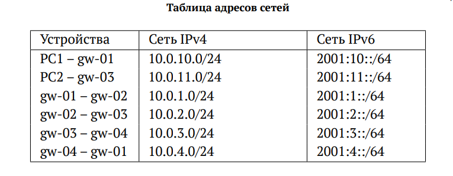

Таблица адресов сетей

## Настройка динамической маршрутизации в сетях IPv4 и IPv6

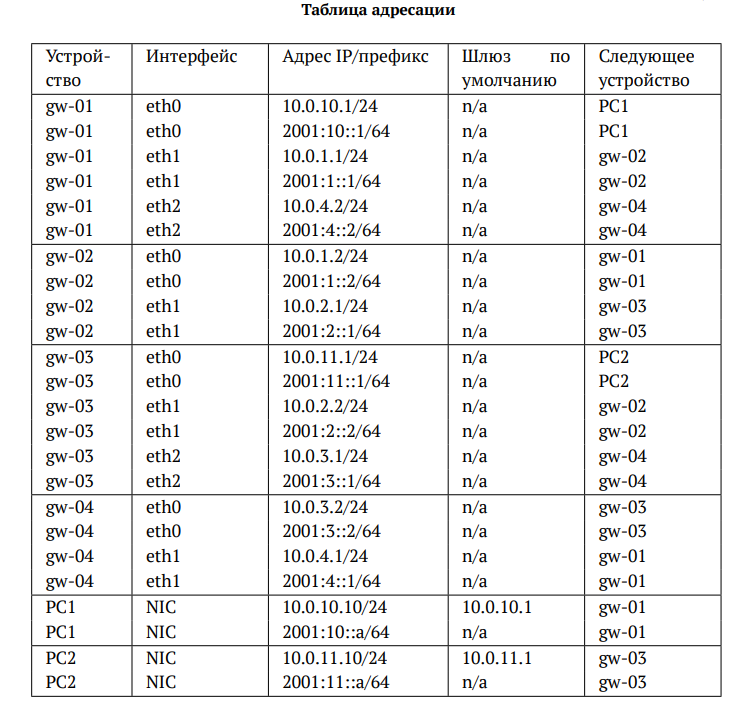

Таблица адресации

## Настройка динамической маршрутизации в сетях IPv4 и IPv6

Изобразим схематично моделируемую сеть. Построим схемы L1 и L3.

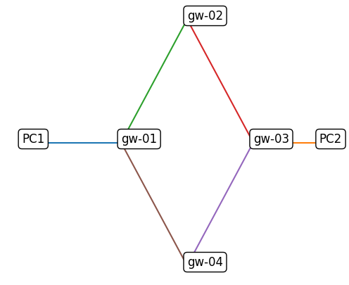

Схема L1

## Настройка динамической маршрутизации в сетях IPv4 и IPv6

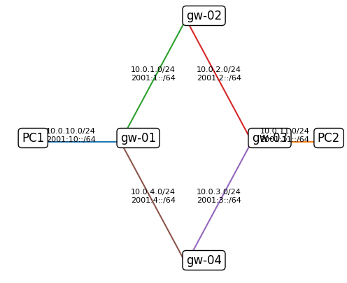

Схема L3

## Настройка динамической маршрутизации в сетях IPv4 и IPv6

Запустим GNS3 VM и GNS3. Создадим новый проект. В рабочем пространстве разместим и соедините устройства в соответствии с топологией, указанной в лабораторной работе. Используем маршрутизаторы FRR. Измените отображаемые названия устройств. Включим захват трафика на соединении между коммутатором sw-01 и маршрутизатором gw-01, а также между коммутатором sw-02 и маршрутизатором gw-03.

## Настройка динамической маршрутизации в сетях IPv4 и IPv6

Присвоим IPv4-адреса оконечным устройствам PC1 и PC2

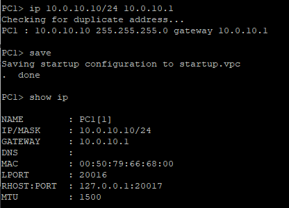

IPv4 в PC1

## Настройка динамической маршрутизации в сетях IPv4 и IPv6

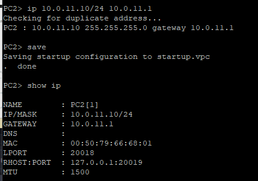

IPv4 в PC2

## Настройка динамической маршрутизации в сетях IPv4 и IPv6

Настроим IPv4-адреса на интерфейсах маршрутизаторов.

msk-antoychubekova-gw-01.

[figure not shown]

Настройка IPv4 в msk-antoychubekova-gw-01

## Настройка динамической маршрутизации в сетях IPv4 и IPv6

msk-antoychubekova-gw-02.

[figure not shown]

Настройка IPv4 в msk-antoychubekova-gw-02

## Настройка динамической маршрутизации в сетях IPv4 и IPv6

msk-antoychubekova-gw-03.

[figure not shown]

Настройка IPv4 в msk-antoychubekova-gw-03

## Настройка динамической маршрутизации в сетях IPv4 и IPv6

msk-antoychubekova-gw-04.

[figure not shown]

Настройка IPv4 в msk-antoychubekova-gw-04

## Настройка динамической маршрутизации в сетях IPv4 и IPv6

Присвоим IPv6-адреса оконечным устройствам PC1 и PC2.

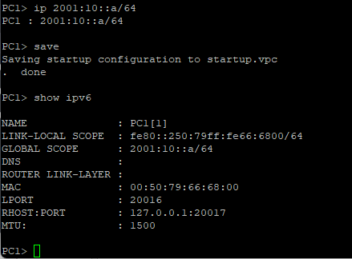

IPv6 в PC1

## Настройка динамической маршрутизации в сетях IPv4 и IPv6

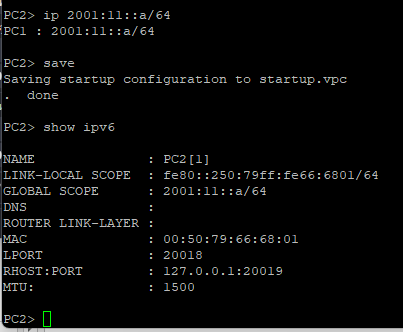

IPv6 в PC2

## Настройка динамической маршрутизации в сетях IPv4 и IPv6

Настроим IPv6-адреса на интерфейсах маршрутизаторов.

msk-antoychubekova-gw-01.

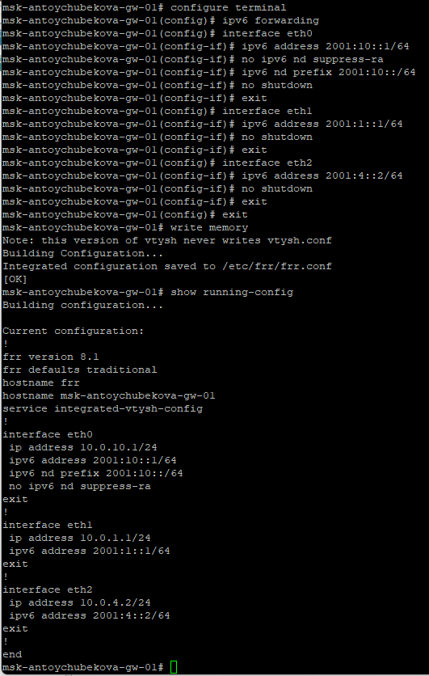

Настройка IPv6 в msk-antoychubekova-gw-01

## Настройка динамической маршрутизации в сетях IPv4 и IPv6

msk-antoychubekova-gw-02.

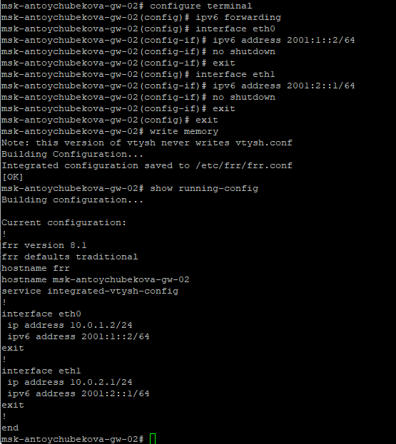

Настройка IPv6 в msk-antoychubekova-gw-02

## Настройка динамической маршрутизации в сетях IPv4 и IPv6

msk-antoychubekova-gw-03.

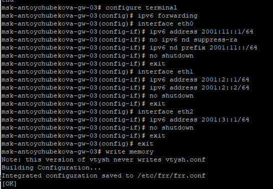

Настройка IPv6 в msk-antoychubekova-gw-03

## Настройка динамической маршрутизации в сетях IPv4 и IPv6

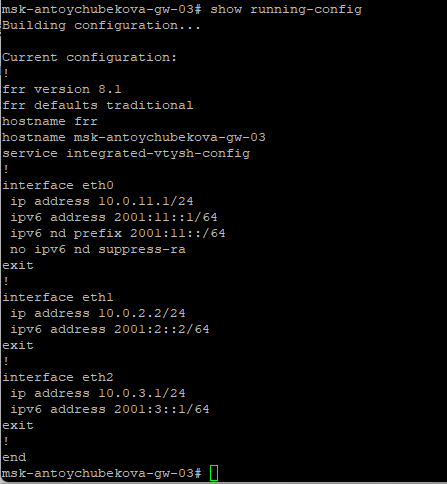

Настройка IPv6 в msk-antoychubekova-gw-03

## Настройка динамической маршрутизации в сетях IPv4 и IPv6

msk-antoychubekova-gw-04.

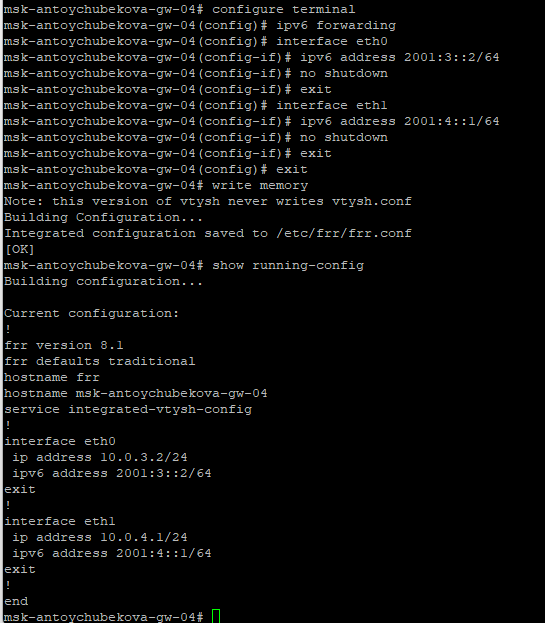

Настройка IPv6 в msk-antoychubekova-gw-04

## Настройка динамической маршрутизации в сетях IPv4 и IPv6

RIPv1 — поддерживает только IPv4, не передает маску сети (классовая маршрутизация). RIPv2 — улучшенная версия для IPv4, использует многоадресную рассылку 224.0.0.9 и передает маску (CIDR). RIPng — версия для IPv6, использует multicast-адрес FF02::9. Маршрутизация включается на уровне интерфейсов, каждый RIPng-процесс имеет локальное имя и может быть несколько процессов на одном маршрутизаторе.

## Настройка динамической маршрутизации в сетях IPv4 и IPv6

На маршрутизаторах настроим RIP в качестве протокола динамической маршрутизации.

msk-antoychubekova-gw-01.

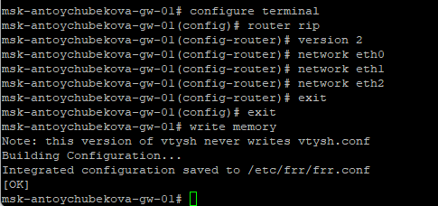

Настройка RIP в msk-antoychubekova-gw-01

## Настройка динамической маршрутизации в сетях IPv4 и IPv6

msk-antoychubekova-gw-02.

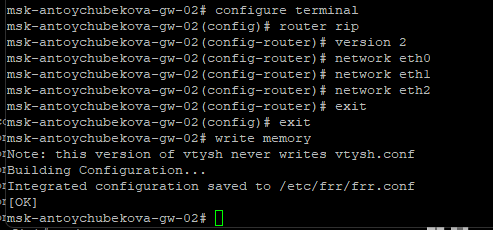

Настройка RIP в msk-antoychubekova-gw-02

## Настройка динамической маршрутизации в сетях IPv4 и IPv6

msk-antoychubekova-gw-03.

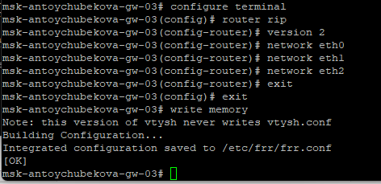

Настройка RIP в msk-antoychubekova-gw-03

## Настройка динамической маршрутизации в сетях IPv4 и IPv6

msk-antoychubekova-gw-04.

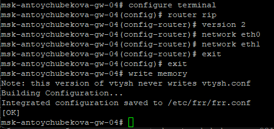

## Настройка динамической маршрутизации в сетях IPv4 и IPv6

Убедимся, что маршрутизация по RIP настроена.

msk-antoychubekova-gw-01.

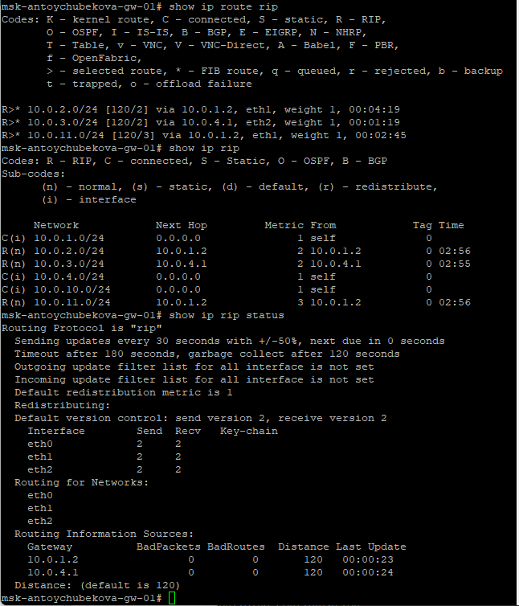

Проверка настройки RIP в msk-antoychubekova-gw-01

## Настройка динамической маршрутизации в сетях IPv4 и IPv6

msk-antoychubekova-gw-02.

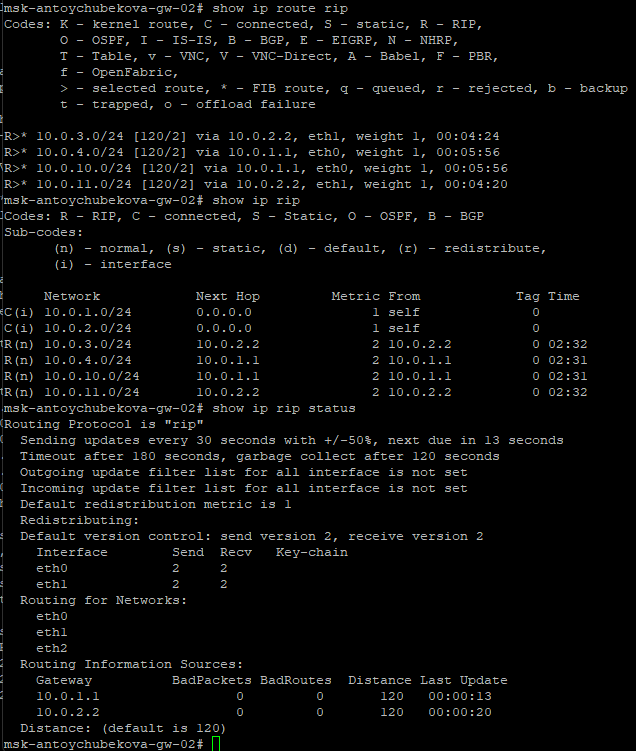

Проверка настройки RIP в msk-antoychubekova-gw-02

## Настройка динамической маршрутизации в сетях IPv4 и IPv6

msk-antoychubekova-gw-03.

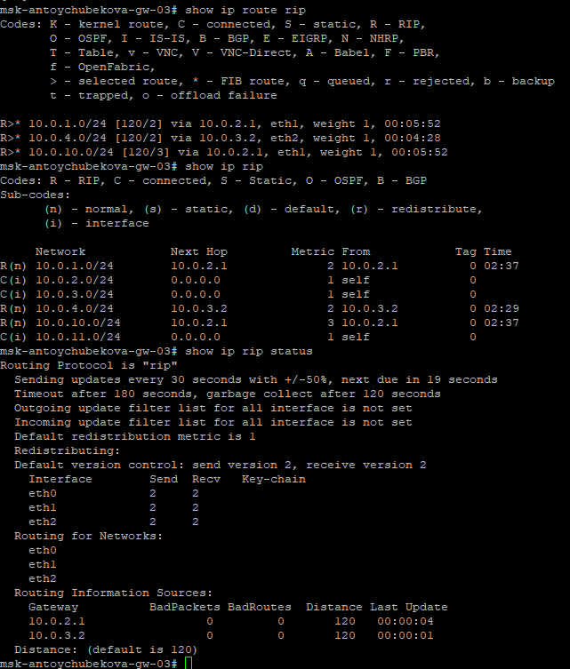

Проверка настройки RIP в msk-antoychubekova-gw-03

## Настройка динамической маршрутизации в сетях IPv4 и IPv6

msk-antoychubekova-gw-04.

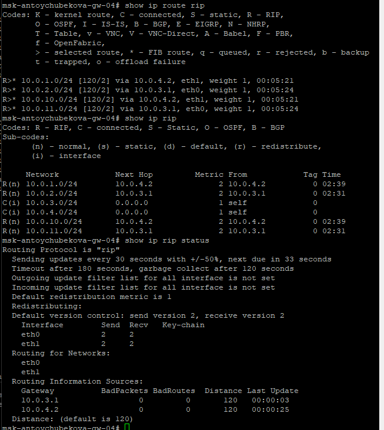

## Настройка динамической маршрутизации в сетях IPv4 и IPv6

Проверим пути прохождения пакетов. С PC1 пропингуем PC2 и определим путь следования пакетов. Мы видим, что у нас все успешно пингуется.

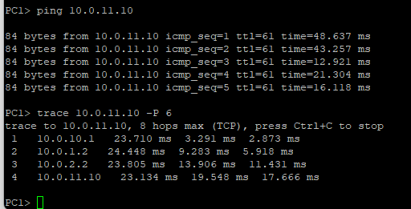

Проверка доступа P1 к Р2

## Настройка динамической маршрутизации в сетях IPv4 и IPv6

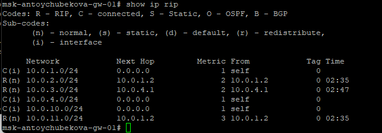

Метрики протокола RIP

## Настройка динамической маршрутизации в сетях IPv4 и IPv6

Предположим, что пакет проходит через маршрутизатор msk-antoychubekova-gw-02. Отключим на маршрутизаторе msk-antoychubekova-gw-02 интерфейс.

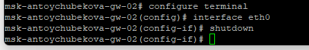

Отключение интерфейса

## Настройка динамической маршрутизации в сетях IPv4 и IPv6

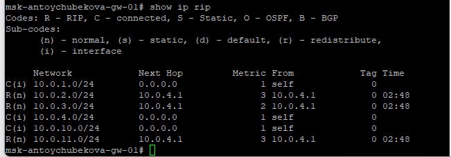

Метрики протокола RIP

## Настройка динамической маршрутизации в сетях IPv4 и IPv6

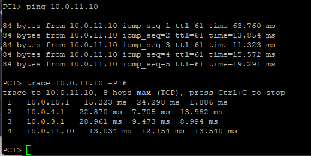

PC1 пинг PC2

## Настройка динамической маршрутизации в сетях IPv4 и IPv6

Включим на маршрутизаторе msk-antoychubekova-gw-02 интерфейс.

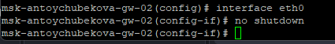

Включение интерфейса